#### Instructions:

For all questions after 10th, Please only use the data specified in the note given just below the question You need to add answers in the same file i.e. PDS_UberDriveProject_Questions.ipynb' and rename that file as 'Name_Date.ipynb'.You can mention the date on which you will be uploading/submitting the file.For e.g. if you plan to submit your assignment on 1st January 2021, you can rename the file as 'STUDENTNAME_01-Jan-2021'

# Load the necessary libraries. Import and load the dataset with a name uber_drives .

```python
import numpy as np
import pandas as pd
import matplotlib.pyplot as plt
%matplotlib inline
import seaborn as sns
from warnings import filterwarnings
filterwarnings("ignore")
```

```python
uber_drives=pd.read_csv('uberdrives.csv')
uber_drives
```

|  | START_DATE* | END_DATE* | CATEGORY* | START* | STOP* | MILES* | PURPOSE* |
| --- | --- | --- | --- | --- | --- | --- | --- |
| 0 | 01-01-2016 21:11 | 01-01-2016 21:17 | Business | Fort Pierce | Fort Pierce | 5.1 | Meal/Entertain |
| 1 | 01-02-2016 01:25 | 01-02-2016 01:37 | Business | Fort Pierce | Fort Pierce | 5.0 | NaN |
| 2 | 01-02-2016 20:25 | 01-02-2016 20:38 | Business | Fort Pierce | Fort Pierce | 4.8 | Errand/Supplies |
| 3 | 01-05-2016 17:31 | 01-05-2016 17:45 | Business | Fort Pierce | Fort Pierce | 4.7 | Meeting |
| 4 | 01-06-2016 14:42 | 01-06-2016 15:49 | Business | Fort Pierce | West Palm Beach | 63.7 | Customer Visit |
| ... | ... | ... | ... | ... | ... | ... | ... |
| 1150 | 12/31/2016 1:07 | 12/31/2016 1:14 | Business | Karachi | Karachi | 0.7 | Meeting |
| 1151 | 12/31/2016 13:24 | 12/31/2016 13:42 | Business | Karachi | Unknown Location | 3.9 | Temporary Site |
| 1152 | 12/31/2016 15:03 | 12/31/2016 15:38 | Business | Unknown Location | Unknown Location | 16.2 | Meeting |
| 1153 | 12/31/2016 21:32 | 12/31/2016 21:50 | Business | Katunayake | Gampaha | 6.4 | Temporary Site |
| 1154 | 12/31/2016 22:08 | 12/31/2016 23:51 | Business | Gampaha | Ilukwatta | 48.2 | Temporary Site |

1155 rows × 7 columns

## Q1. Show the last 10 records of the dataset. (2 point)

```python
uber_drives.tail(10)
```

|  | START_DATE* | END_DATE* | CATEGORY* | START* | STOP* | MILES* | PURPOSE* |
| --- | --- | --- | --- | --- | --- | --- | --- |
| 1145 | 12/30/2016 10:15 | 12/30/2016 10:33 | Business | Karachi | Karachi | 2.8 | Errand/Supplies |
| 1146 | 12/30/2016 11:31 | 12/30/2016 11:56 | Business | Karachi | Karachi | 2.9 | Errand/Supplies |
| 1147 | 12/30/2016 15:41 | 12/30/2016 16:03 | Business | Karachi | Karachi | 4.6 | Errand/Supplies |
| 1148 | 12/30/2016 16:45 | 12/30/2016 17:08 | Business | Karachi | Karachi | 4.6 | Meeting |
| 1149 | 12/30/2016 23:06 | 12/30/2016 23:10 | Business | Karachi | Karachi | 0.8 | Customer Visit |
| 1150 | 12/31/2016 1:07 | 12/31/2016 1:14 | Business | Karachi | Karachi | 0.7 | Meeting |
| 1151 | 12/31/2016 13:24 | 12/31/2016 13:42 | Business | Karachi | Unknown Location | 3.9 | Temporary Site |
| 1152 | 12/31/2016 15:03 | 12/31/2016 15:38 | Business | Unknown Location | Unknown Location | 16.2 | Meeting |
| 1153 | 12/31/2016 21:32 | 12/31/2016 21:50 | Business | Katunayake | Gampaha | 6.4 | Temporary Site |
| 1154 | 12/31/2016 22:08 | 12/31/2016 23:51 | Business | Gampaha | Ilukwatta | 48.2 | Temporary Site |

## Q2. Show the first 10 records of the dataset. (2 points)

```python
uber_drives.head(10)
```

|  | START_DATE* | END_DATE* | CATEGORY* | START* | STOP* | MILES* | PURPOSE* |
| --- | --- | --- | --- | --- | --- | --- | --- |
| 0 | 01-01-2016 21:11 | 01-01-2016 21:17 | Business | Fort Pierce | Fort Pierce | 5.1 | Meal/Entertain |
| 1 | 01-02-2016 01:25 | 01-02-2016 01:37 | Business | Fort Pierce | Fort Pierce | 5.0 | NaN |
| 2 | 01-02-2016 20:25 | 01-02-2016 20:38 | Business | Fort Pierce | Fort Pierce | 4.8 | Errand/Supplies |
| 3 | 01-05-2016 17:31 | 01-05-2016 17:45 | Business | Fort Pierce | Fort Pierce | 4.7 | Meeting |
| 4 | 01-06-2016 14:42 | 01-06-2016 15:49 | Business | Fort Pierce | West Palm Beach | 63.7 | Customer Visit |
| 5 | 01-06-2016 17:15 | 01-06-2016 17:19 | Business | West Palm Beach | West Palm Beach | 4.3 | Meal/Entertain |
| 6 | 01-06-2016 17:30 | 01-06-2016 17:35 | Business | West Palm Beach | Palm Beach | 7.1 | Meeting |
| 7 | 01-07-2016 13:27 | 01-07-2016 13:33 | Business | Cary | Cary | 0.8 | Meeting |
| 8 | 01-10-2016 08:05 | 01-10-2016 08:25 | Business | Cary | Morrisville | 8.3 | Meeting |
| 9 | 01-10-2016 12:17 | 01-10-2016 12:44 | Business | Jamaica | New York | 16.5 | Customer Visit |

## Q3. Show the dimension(number of rows and columns) of the dataset. (2 points)

```python
uber_drives.shape
```

```
(1155, 7)
```

The number of rows in the uberdrives data set is 1155 and the number of columns is 7.

## Q4. Show the size (Total number of elements) of the dataset. (2 points)

```python
uber_drives.size
```

```
8085
```

The total number of elements in the dataset is 8085

## Q5. Display the information about all the variables of the data set. What can you infer from the output?(1 +2 points)

#### Hint: Information includes - Total number of columns,variable data-types, number of non-null values in a variable, and usage

```python
uber_drives.info()
```

```
<class 'pandas.core.frame.DataFrame'>
RangeIndex: 1155 entries, 0 to 1154
Data columns (total 7 columns):
 #   Column       Non-Null Count  Dtype
---  ------       --------------  -----
 0   START_DATE*  1155 non-null   object
 1   END_DATE*    1155 non-null   object
 2   CATEGORY*    1155 non-null   object
 3   START*       1155 non-null   object
 4   STOP*        1155 non-null   object
 5   MILES*       1155 non-null   float64
 6   PURPOSE*     653 non-null    object
dtypes: float64(1), object(6)
memory usage: 63.3+ KB
```

From the above information we can infer that :-

1) Identifying null values in the the column 'PURPOSE' of the dataset, implies that it was not a mandatory data for users to fill out, whereas the other fields were automatically generated considering user inputs during the booking of the ride.

2) Wherever the data is being recorded it is made sure that the column 'MILES' accepts only numerical values.

## Q6. Check for missing values. (2 points)

#### Note: Output should contain only one boolean value

```python
uber_drives.isnull().sum().any()
```

```
True
```

Above output indicates there are null values present in the dataset provided.

## Q7. How many missing values are present in the entire dataset? (2 points)

```python
uber_drives.isnull().sum()
```

```
START_DATE*      0
END_DATE*        0
CATEGORY*        0
START*           0
STOP*            0
MILES*           0
PURPOSE*       502
dtype: int64
```

Above information indicates there are 502 null values in the column 'PURPOSE' whereas all the other columns have none.

## Q8. Get the summary of the original data. (2 points).

#### Hint: Summary includes- Count,Mean, Std, Min, 25%,50%,75% and max

```python
uber_drives.describe().T
```

|  | count | mean | std | min | 25% | 50% | 75% | max |
| --- | --- | --- | --- | --- | --- | --- | --- | --- |
| MILES* | 1155.0 | 10.56684 | 21.579106 | 0.5 | 2.9 | 6.0 | 10.4 | 310.3 |

Above output displays the summary of the uber drives dataset showing count, mean, standard deviation, minimum, (25th, 50th, and 75th percentiles) and maximum of all the values of the column 'MILES'.

## Q9. Drop the missing values and store the data in a new dataframe (name it"df") (2-points)

#### Note: Dataframe "df" will not contain any missing value

```python
df=uber_drives.copy()
```

```python
df.dropna(axis=0,inplace=True)
df
```

|  | START_DATE* | END_DATE* | CATEGORY* | START* | STOP* | MILES* | PURPOSE* |
| --- | --- | --- | --- | --- | --- | --- | --- |
| 0 | 01-01-2016 21:11 | 01-01-2016 21:17 | Business | Fort Pierce | Fort Pierce | 5.1 | Meal/Entertain |
| 2 | 01-02-2016 20:25 | 01-02-2016 20:38 | Business | Fort Pierce | Fort Pierce | 4.8 | Errand/Supplies |
| 3 | 01-05-2016 17:31 | 01-05-2016 17:45 | Business | Fort Pierce | Fort Pierce | 4.7 | Meeting |
| 4 | 01-06-2016 14:42 | 01-06-2016 15:49 | Business | Fort Pierce | West Palm Beach | 63.7 | Customer Visit |
| 5 | 01-06-2016 17:15 | 01-06-2016 17:19 | Business | West Palm Beach | West Palm Beach | 4.3 | Meal/Entertain |
| ... | ... | ... | ... | ... | ... | ... | ... |
| 1150 | 12/31/2016 1:07 | 12/31/2016 1:14 | Business | Karachi | Karachi | 0.7 | Meeting |
| 1151 | 12/31/2016 13:24 | 12/31/2016 13:42 | Business | Karachi | Unknown Location | 3.9 | Temporary Site |
| 1152 | 12/31/2016 15:03 | 12/31/2016 15:38 | Business | Unknown Location | Unknown Location | 16.2 | Meeting |
| 1153 | 12/31/2016 21:32 | 12/31/2016 21:50 | Business | Katunayake | Gampaha | 6.4 | Temporary Site |
| 1154 | 12/31/2016 22:08 | 12/31/2016 23:51 | Business | Gampaha | Ilukwatta | 48.2 | Temporary Site |

653 rows × 7 columns

Above mentioned is the new dataframe with no null values. Hence, it has less number of entries compared to the original dataset (i.e. lesser number of rows).

## Q10. Check the information of the dataframe(df). (1 points)

#### Hint: Information includes - Total number of columns,variable data-types, number of non-null values in a variable, and usage

```python
df.info()
```

```
<class 'pandas.core.frame.DataFrame'>
Int64Index: 653 entries, 0 to 1154
Data columns (total 7 columns):
 #   Column       Non-Null Count  Dtype
---  ------       --------------  -----
 0   START_DATE*  653 non-null    object
 1   END_DATE*    653 non-null    object
 2   CATEGORY*    653 non-null    object
 3   START*       653 non-null    object
 4   STOP*        653 non-null    object
 5   MILES*       653 non-null    float64
 6   PURPOSE*     653 non-null    object
dtypes: float64(1), object(6)
memory usage: 40.8+ KB
```

## Q11. Get the unique start locations. (2 points)

#### Note: This question is based on the dataframe with no 'NA' values

```python
df['START*'].nunique()
```

```
131
```

There are 131 unique start locations in the dataframe with no NA values.

## Q12. What is the total number of unique start locations? (2 points)

#### Note: Use the original dataframe without dropping 'NA' values

```python
uber_drives['START*'].nunique()
```

```
176
```

There are 176 unique start locations in the dataframe without dropping NA values.

## Q13. What is the total number of unique stop locations. (2 points)

#### Note: Use the original dataframe without dropping 'NA' values.

```python
uber_drives['STOP*'].nunique()
```

```
187
```

There are 187 unique stop locations in the dataframe without dropping NA values.

## Q14. Display all Uber trips that has the starting point as San Francisco. (2 points)

#### Note: Use the original dataframe without dropping the 'NA' values.

```python
df1=uber_drives[(uber_drives["START*"]=='San Francisco')]
df1
```

|  | START_DATE* | END_DATE* | CATEGORY* | START* | STOP* | MILES* | PURPOSE* |
| --- | --- | --- | --- | --- | --- | --- | --- |
| 362 | 05-09-2016 14:39 | 05-09-2016 15:06 | Business | San Francisco | Palo Alto | 20.5 | Between Offices |
| 440 | 6/14/2016 16:09 | 6/14/2016 16:39 | Business | San Francisco | Emeryville | 11.6 | Meeting |
| 836 | 10/19/2016 14:02 | 10/19/2016 14:31 | Business | San Francisco | Berkeley | 10.8 | NaN |
| 917 | 11-07-2016 19:17 | 11-07-2016 19:57 | Business | San Francisco | Berkeley | 13.2 | Between Offices |
| 919 | 11-08-2016 12:16 | 11-08-2016 12:49 | Business | San Francisco | Berkeley | 11.3 | Meeting |
| 927 | 11-09-2016 18:40 | 11-09-2016 19:17 | Business | San Francisco | Oakland | 12.7 | Customer Visit |
| 933 | 11-10-2016 15:17 | 11-10-2016 15:22 | Business | San Francisco | Oakland | 9.9 | Temporary Site |
| 966 | 11/15/2016 20:44 | 11/15/2016 21:00 | Business | San Francisco | Berkeley | 11.8 | Temporary Site |

Above is the dataframe with all the Uber trips that have starting point as San Francisco.

## Q15. What is the most popular starting point for the Uber drivers? (2 points)

#### Note: Use the original dataframe without dropping the 'NA' values.

#### Hint:Popular means the place that is visited the most

```python
uber_drives['START*'].value_counts()
```

```
Cary                  201
Unknown Location      148
Morrisville            85
Whitebridge            68
Islamabad              57
                     ...
Financial District      1
Cory                    1
Sunnyside               1
Red River District      1
Fairmont                1
Name: START*, Length: 176, dtype: int64
```

We can infer from the above information that the most popular starting point for Uber drivers is Cary (201 times).

## Q16. What is the most popular dropping point for the Uber drivers? (2 points)

#### Note: Use the original dataframe without dropping the 'NA' values.

#### Hint: Popular means the place that is visited the most

```python
uber_drives['STOP*'].value_counts()
```

```
Cary                  203
Unknown Location      149
Morrisville            84
Whitebridge            65
Islamabad              58
                     ...
Queens County           1
Bay Farm Island         1
St Thomas               1
K Street                1
Southwest Berkeley      1
Name: STOP*, Length: 187, dtype: int64
```

We can infer from the above information that the most popular dropping or stoppage point for Uber drivers is Cary (203 times).

## Q17. What is the most frequent route taken by Uber drivers. (3 points)

#### Note: This question is based on the new dataframe with no 'na' values.

#### Hint-Print the most frequent route taken by Uber drivers (Route= combination of START & END points present in the Data set).

```python
df['Route'] = df['START*']+' to '+df['STOP*']
df
```

|  | START_DATE* | END_DATE* | CATEGORY* | START* | STOP* | MILES* | PURPOSE* | Route |
| --- | --- | --- | --- | --- | --- | --- | --- | --- |
| 0 | 01-01-2016 21:11 | 01-01-2016 21:17 | Business | Fort Pierce | Fort Pierce | 5.1 | Meal/Entertain | Fort Pierce to Fort Pierce |
| 2 | 01-02-2016 20:25 | 01-02-2016 20:38 | Business | Fort Pierce | Fort Pierce | 4.8 | Errand/Supplies | Fort Pierce to Fort Pierce |
| 3 | 01-05-2016 17:31 | 01-05-2016 17:45 | Business | Fort Pierce | Fort Pierce | 4.7 | Meeting | Fort Pierce to Fort Pierce |
| 4 | 01-06-2016 14:42 | 01-06-2016 15:49 | Business | Fort Pierce | West Palm Beach | 63.7 | Customer Visit | Fort Pierce to West Palm Beach |
| 5 | 01-06-2016 17:15 | 01-06-2016 17:19 | Business | West Palm Beach | West Palm Beach | 4.3 | Meal/Entertain | West Palm Beach to West Palm Beach |
| ... | ... | ... | ... | ... | ... | ... | ... | ... |
| 1150 | 12/31/2016 1:07 | 12/31/2016 1:14 | Business | Karachi | Karachi | 0.7 | Meeting | Karachi to Karachi |
| 1151 | 12/31/2016 13:24 | 12/31/2016 13:42 | Business | Karachi | Unknown Location | 3.9 | Temporary Site | Karachi to Unknown Location |
| 1152 | 12/31/2016 15:03 | 12/31/2016 15:38 | Business | Unknown Location | Unknown Location | 16.2 | Meeting | Unknown Location to Unknown Location |
| 1153 | 12/31/2016 21:32 | 12/31/2016 21:50 | Business | Katunayake | Gampaha | 6.4 | Temporary Site | Katunayake to Gampaha |
| 1154 | 12/31/2016 22:08 | 12/31/2016 23:51 | Business | Gampaha | Ilukwatta | 48.2 | Temporary Site | Gampaha to Ilukwatta |

653 rows × 8 columns

```python
df['Route'].value_counts()
```

```
Cary to Morrisville                     52
Morrisville to Cary                     51
Cary to Cary                            44
Cary to Durham                          30
Unknown Location to Unknown Location    30
                                        ..
Whitebridge to Macgregor Downs           1
Noorpur Shahan to Unknown Location       1
Rawalpindi to Islamabad                  1
Northwoods to Preston                    1
Latta to Jacksonville                    1
Name: Route, Length: 239, dtype: int64
```

We can infer from the above information that the most frequent route taken by Uber drivers is from Cary to Morrisville (52 trips) followed by Morrisville to Carry (51 trips).

## Q18. Display all types of purposes for the trip in an array. (2 points)

#### Note: This question is based on the new dataframe with no 'NA' values.

```python
df['PURPOSE*'].value_counts().index
```

```
Index(['Meeting', 'Meal/Entertain', 'Errand/Supplies', 'Customer Visit',
       'Temporary Site', 'Between Offices', 'Moving', 'Airport/Travel',
       'Commute', 'Charity ($)'],
      dtype='object')
```

Above mentioned are all the types of purposes for the trip in the dataframe with no 'NA' values.

## Q19. Plot a bar graph of Purpose vs Miles(Distance). What can you infer from the plot(2 +2 points)

#### Note: Use the original dataframe without dropping the 'NA' values.

#### Hint:You have to plot total/sum miles per purpose

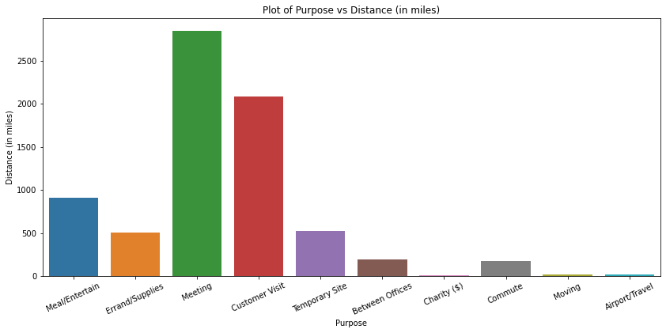

```python
plt.figure(figsize=(14,6))
sns.barplot(x='PURPOSE*',y='MILES*',estimator=np.sum,data=uber_drives,ci=None)
plt.xticks(rotation=25);
plt.title('Plot of Purpose vs Distance (in miles)');
plt.xlabel('Purpose');
plt.ylabel('Distance (in miles)');
```

We can infer from the graph above that

1) The most distance travelled by the customers were for the 'Meeting' and 'Customer Visit' purposes.

2) Whereas the least distance travelled by the customers were for the 'Chairty', 'Airport/Travel' and 'Moving' purposes in no definite order.

```python
df2 = uber_drives.copy()
df2.fillna('Not Specified',inplace=True)
df2;
```

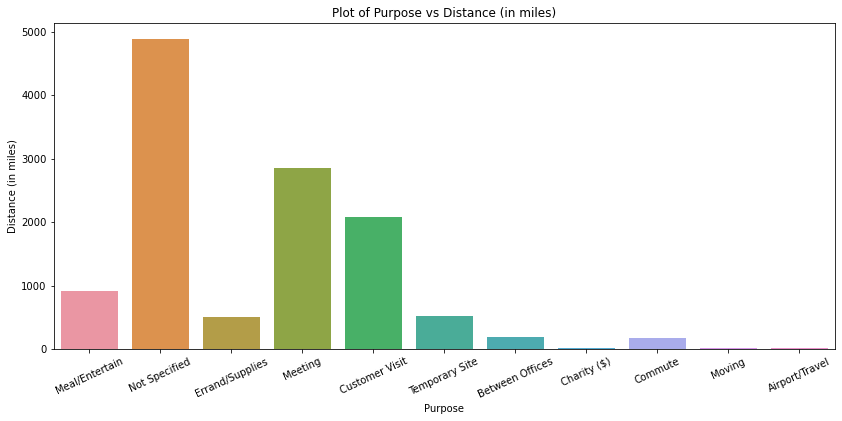

```python
plt.figure(figsize=(14,6))
sns.barplot(x='PURPOSE*',y='MILES*',estimator=np.sum,data=df2,ci=None)
plt.xticks(rotation=25);
plt.title('Plot of Purpose vs Distance (in miles)');
plt.xlabel('Purpose');
plt.ylabel('Distance (in miles)');
```

We can infer from the graph above that

1) If we include null values of the column 'PURPOSE', we can see that the distance travelled by 'Not Specified' purpose is the highest followed by 'Meeting' and 'Customer Visit' purposes.

2) Whereas the distance travelled by the customers for the 'Chairty' , 'Airport/Travel' and 'Moving' purposes is significantly low.

If any decision regarding to the purpose of uber ride is to be taken by the company, we need to take all the null values into account as it represents the largest distance travelled by the rides (in miles).

## Q20. Display a dataframe of Purpose and the total distance travelled for that particular Purpose. (3 points)

#### Note: Use the original dataframe without dropping "NA" values

Below is the dataframe that does not include null values of the column 'PURPOSE'

```python
df3 = uber_drives.groupby('PURPOSE*')['MILES*'].sum()
df3.sort_values(ascending=False)
```

```
PURPOSE*
Meeting            2851.3
Customer Visit     2089.5
Meal/Entertain      911.7
Temporary Site      523.7
Errand/Supplies     508.0
Between Offices     197.0
Commute             180.2
Moving               18.2
Airport/Travel       16.5
Charity ($)          15.1
Name: MILES*, dtype: float64
```

We can infer that the total distance travelled for the purpose of 'Meeting' is the highest (2851.3 miles), whereas, it is the least for 'Charity' (15.1 miles).

Below is the dataframe that includes null values of the column 'PURPOSE'

```python
df4 = df2.groupby('PURPOSE*')['MILES*'].sum()
df4.sort_values(ascending=False)
```

```
PURPOSE*
Not Specified      4893.5
Meeting            2851.3
Customer Visit     2089.5
Meal/Entertain      911.7
Temporary Site      523.7
Errand/Supplies     508.0
Between Offices     197.0
Commute             180.2
Moving               18.2
Airport/Travel       16.5
Charity ($)          15.1
Name: MILES*, dtype: float64
```

We can infer that the total distance travelled for the purpose of 'Not Specified' is the highest (4893.5 miles), Whereas it is the least for Charity (15.1 miles).

## Q21. Generate a plot showing count of trips vs category of trips. What can you infer from the plot (2 +1 points)

#### Note: Use the original dataframe without dropping the 'NA' values.

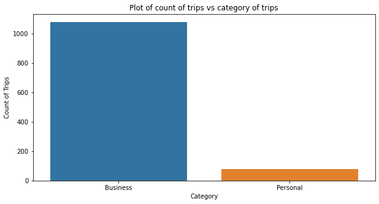

```python
plt.figure(figsize=(10,5))
sns.countplot(uber_drives['CATEGORY*']);
plt.title('Plot of count of trips vs category of trips');
plt.xlabel('Category');
plt.ylabel('Count of Trips');
```

We can infer from the graph above that the number of business category trips are significantly larger than the personal category trips of customers.

## Q22. What percentage of Miles were clocked under Business Category and what percentage of Miles were clocked under Personal Category ? (3 points)

### Note:Use the original dataframe without dropping the 'NA' values.

```python
df5 = uber_drives.groupby('CATEGORY*')['MILES*'].sum()
df5
```

```
CATEGORY*
Business    11487.0
Personal      717.7
Name: MILES*, dtype: float64
```

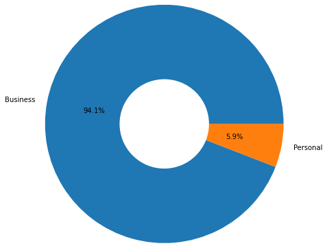

```python
plt.pie(df5,labels=df5.index,autopct='%1.1f%%',radius=2)
plt.pie([1],colors=['w'],radius=0.75)
plt.show()
```

From the above pie chart we can infer that the percentage of Miles clocked under Business Category is 94.1% whereas the percentage of Miles clocked under Personal Category is 5.9%.

*THE END*